# Extending the Linear Model

## Example: shipping books

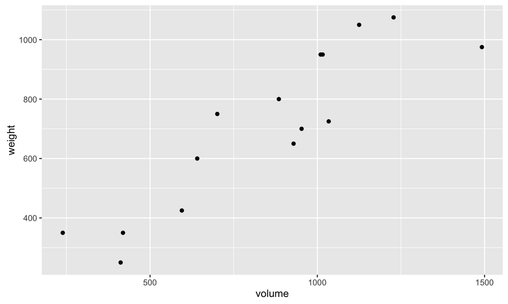

```r
qplot(x = volume, y = weight, data = books)
```

## Example: shipping books

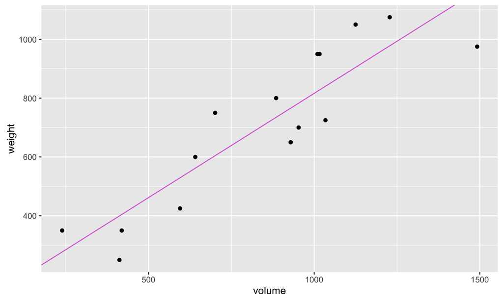

```r
qplot(x = volume, y = weight, data = books) +
  geom_abline(intercept = m1$coef[1], slope = m1$coef[2], col = "orchid")
```

## Fitting the linear model

```r
m1 <- lm(weight ~ volume, data = books)
summary(m1)
```

```
##
## Call:
## lm(formula = weight ~ volume, data = books)
##
## Residuals:
##    Min     1Q Median     3Q    Max
## -190.0 -109.9   38.1  109.7  145.6
##
## Coefficients:
##             Estimate Std. Error t value Pr(>|t|)
## (Intercept) 107.6793    88.3776    1.22     0.24
## volume        0.7086     0.0975    7.27  6.3e-06 ***
## ---
## Signif. codes:  0 '***' 0.001 '**' 0.01 '*' 0.05 '.' 0.1 ' ' 1
##
## Residual standard error: 124 on 13 degrees of freedom
## Multiple R-squared:  0.803,  Adjusted R-squared:  0.787
## F-statistic: 52.9 on 1 and 13 DF,  p-value: 6.26e-06
```

## Multiple Regression

Allows us create a model to explain one \(numerical\) variable, the response, as a linear function of many explanatory variables that can be both \(numerical\) and \(categorical\).

We posit the true model:

\[ Y = \beta_0 + \beta_1 X_1 + \beta_2 X_2 + \ldots + \beta_p X_p + \epsilon; \quad \epsilon \sim N(0, \sigma^2) \]

## Estimating \(\beta_0, \beta_1\) etc.

In least-squares regression, we're still finding the estimates that minimize the sum of squared residuals.

\[ e_i = y_i - \hat{y}_i \]

\[ \sum_{i = 1}^n e_i^2 \]

And yes, they have a closed-form solution.

\[ \hat{\beta} = (X'X)^{-1}X'Y \]

In R:

```r
lm(Y ~ X1 + X2 + ... + Xp, data = mydata)
```

## Example: shipping books

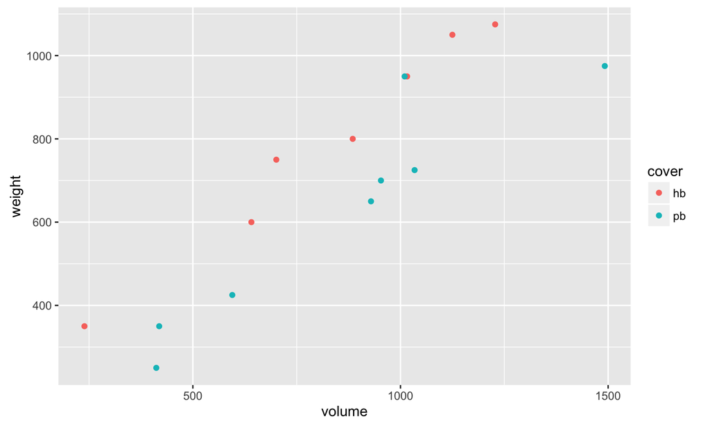

```r
qplot(x = volume, y = weight, color = cover, data = books)
```

## Example: shipping books

```r
m2 <- lm(weight ~ volume + cover, data = books)
summary(m2)
```

```
##
## Call:
## lm(formula = weight ~ volume + cover, data = books)
##
## Residuals:
##    Min     1Q Median     3Q    Max
## -110.1  -32.3  -16.1   28.9  210.9
##
## Coefficients:
##              Estimate Std. Error t value Pr(>|t|)
## (Intercept)  197.9628    59.1927    3.34  0.00584 **
## volume         0.7180     0.0615   11.67  6.6e-08 ***
## coverpb     -184.0473    40.4942   -4.55  0.00067 ***
## ---
## Signif. codes:  0 '***' 0.001 '**' 0.01 '*' 0.05 '.' 0.1 ' ' 1
##
## Residual standard error: 78.2 on 12 degrees of freedom
## Multiple R-squared:  0.927,  Adjusted R-squared:  0.915
## F-statistic: 76.7 on 2 and 12 DF,  p-value: 1.45e-07
```

## Example: shipping books

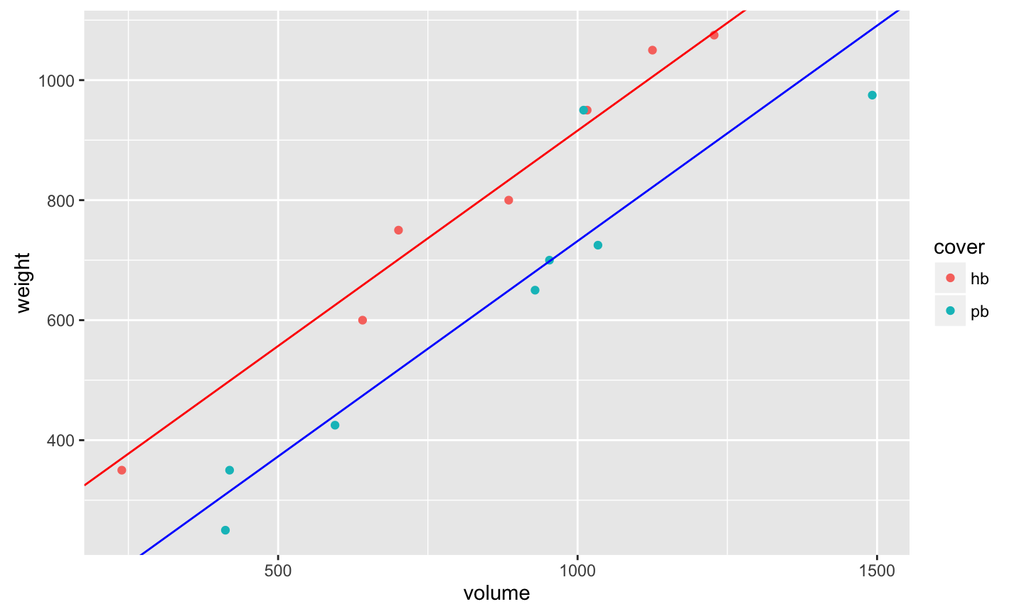

## MLR slope interpretation

The slope corresponding to the dummy variable tell us:

- How much vertical separation there is between our lines
- How much `weight` is expected to increase if `cover` goes from 0 to 1 and `volume` is left unchanged.

Each \(\hat{\beta}_i\) tells you how much you expect the \(Y\) to change when you change the \(X_i\), while **holding all other variables constant**.

## Activity

Load in the LA homes data set and fit the following model:

\[ logprice \sim logsqft + bed + city \]

```r
LA <- read.csv("http://andrewpbray.github.io/data/LA.csv")
```

1. What is the geometry of this model?
2. What appears to be the reference level for `city`?
3. In the context of this problem, what is suggested by the *sign* of the coefficient for `bed`? Do this make sense to you?